# Tugas TPG

Nisrina Suci Fadila (G1401231021)

2025-11-12

# **ANALISIS GEROMBOL**

## **A. Hierarchical Clustering**

## Standarisasi & Matriks Jarak

```r
library(cluster)
library(factoextra)
library(clusterCrit)
library(dplyr)
```

```r
library(ggplot2)
library(tidyr)
library(scales)
library(RColorBrewer)
```

```r
data <- read.csv("D:\\semester 5\\TPG\\Ship_Performance_Dataset.csv")
data
```

```
##         Jarak Berat.muatan Biaya.operasional Pendapatan
## 1    751.2816   1369.10620         293070.46  549636.06
## 2    610.3142    895.08854         430248.33  314689.79
## 3   1214.8410   1311.77914         112697.05  257162.23
## 4   1570.6739    920.76990         143043.83  420477.26
## 5   1200.8543   1650.84354         125028.04  604435.64
## 6    724.9372    159.15417         362041.44  750232.47
## 7   1019.6590    462.05751         132059.30  759437.93
## 8   1567.5715    671.33768         461436.93  652000.29
## 9    662.5819    859.58673         405039.02  420410.06
## 10   484.4319   1610.54734         347764.36  621037.58
## 11  1290.7068   1733.21465         368724.60  452160.89
## 12  1403.0699    589.04488         202701.86  752855.02
## 13  1725.7346   1761.20604          60779.58  395852.28
## 14   181.6093   1070.61495         249327.84  423469.54
```

[output cut: 185 more lines]

```r
str(data)
```

```
## 'data.frame':    199 obs. of  4 variables:
##  $ Jarak            : num  751 610 1215 1571 1201 ...
##  $ Berat.muatan     : num  1369 895 1312 921 1651 ...
##  $ Biaya.operasional: num  293070 430248 112697 143044 125028 ...
##  $ Pendapatan       : num  549636 314690 257162 420477 604436 ...
```

```r
data_scaled <- scale(data)
head(data_scaled)
```

```
##           Jarak Berat.muatan Biaya.operasional Pendapatan
## [1,] -0.5445004    0.6519404         0.2303275  0.1419936
## [2,] -0.7924965   -0.2232533         1.2050521 -0.7405418
## [3,]  0.2710142    0.5460956        -1.0513252 -0.9566343
## [4,]  0.8970112   -0.1758370        -0.8356946 -0.3431693
## [5,]  0.2464080    1.1721209        -0.9637067  0.3478388
## [6,] -0.5908465   -1.5820321         0.7204044  0.8954996
```

```r
# Matriks jarak Euclidean
dist_matrix <- dist(data_scaled, method = "euclidean")#"euclidean", "maximum", "manhattan", "canberra", "binary" or "minkowski"
head(dist_matrix,10)
```

```
##  [1] 1.5988817 1.8777338 2.0334594 1.5376001 2.4084700 2.2265581 2.3024054
##  [8] 1.3333979 0.8012964 1.3324959
```

```r
# Hierarchical clustering dengan metode Ward
hc_ward <- hclust(dist_matrix, method = "ward.D2") #"single", "complete", "average" (= UPGMA), "mcquitty" "median" or "centroid"
hc_ward
```

```
##
## Call:
## hclust(d = dist_matrix, method = "ward.D2")
##
## Cluster method   : ward.D2
## Distance         : euclidean
## Number of objects: 199
```

## Dendrogram

Dendrogram menggambarkan proses penggabungan antar objek atau cluster berdasarkan tingkat kemiripan. Setiap percabangan menunjukkan dua cluster yang digabung, dengan tinggi cabang mencerminkan jarak antar cluster.

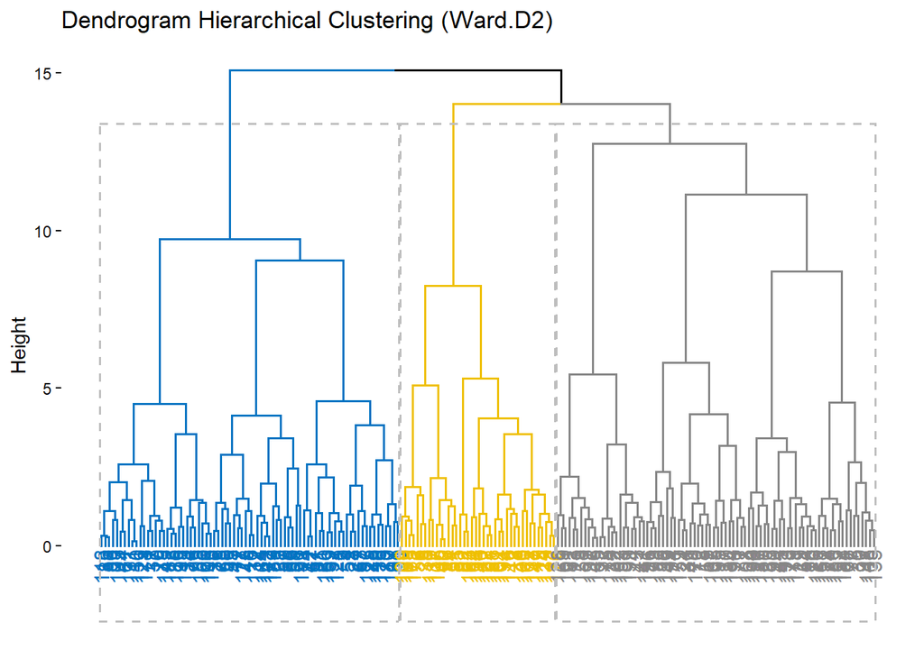

```r
fviz_dend(hc_ward, k = 3, rect = TRUE, palette = "jco",
main = "Dendrogram Hierarchical Clustering (Ward.D2)")
```

## Hasil Clustering

```r
cluster_hc <- cutree(hc_ward, k = 3)
table(cluster_hc)
```

```
## cluster_hc
##  1  2  3
## 77 82 40
```

```r
head(data.frame(Observasi = 1:length(cluster_hc),
           Cluster = cluster_hc),10)
```

```
##    Observasi Cluster
## 1          1       1
## 2          2       1
## 3          3       2
## 4          4       2
## 5          5       2
## 6          6       3
## 7          7       2
## 8          8       3
## 9          9       1
## 10        10       1
```

## Komponen hasil

Fungsi `hclust()` menghasilkan sejumlah komponen yang menjelaskan proses pengelompokan.  
Beberapa komponen penting antara lain:

- **merge:** pasangan cluster yang digabung di setiap langkah,
- **height:** jarak antar cluster pada saat digabung,
- **order:** urutan observasi di dendrogram,
- **labels:** label atau nama observasi,
- **method & dist.method:** metode penggabungan dan jenis jarak yang digunakan.

```r
names(hc_ward)
```

```
## [1] "merge"       "height"      "order"       "labels"      "method"
## [6] "call"        "dist.method"
```

```r
head(hc_ward$merge, 10)
```

```
##       [,1] [,2]
##  [1,]  -11 -150
##  [2,]  -40  -96
##  [3,] -146 -183
##  [4,]  -32  -75
##  [5,]  -83  -86
##  [6,]  -42  -67
##  [7,] -143 -177
##  [8,] -118    5
##  [9,] -112 -176
## [10,]  -16 -132
```

```r
hc_ward$height
```

```
##   [1]  0.1471228  0.2270737  0.2736707  0.2832656  0.2938680  0.3094178
##   [7]  0.3146287  0.3246925  0.3364029  0.3489927  0.3575965  0.3589286
##  [13]  0.3980279  0.3985071  0.4407665  0.4456681  0.4500469  0.4546585
##  [19]  0.4557595  0.4581993  0.4671875  0.4722374  0.4835865  0.4849118
##  [25]  0.4849827  0.4962246  0.4976558  0.4995937  0.5111611  0.5295885
##  [31]  0.5469333  0.5490173  0.5537610  0.5601718  0.5663717  0.5687661
##  [37]  0.5785513  0.5786358  0.5796815  0.5817068  0.5846991  0.5880740
##  [43]  0.5889868  0.5894120  0.5946888  0.6012999  0.6062182  0.6096643
##  [49]  0.6211631  0.6211825  0.6244961  0.6265436  0.6368146  0.6372272
##  [55]  0.6406225  0.6434901  0.6503970  0.6622698  0.6742989  0.6825528
##  [61]  0.6842513  0.7080064  0.7095947  0.7144339  0.7260035  0.7300621
##  [67]  0.7312826  0.7337689  0.7455594  0.7607390  0.7670649  0.7703272
##  [73]  0.7788078  0.7863807  0.7870293  0.7929550  0.7979244  0.7997999
##  [79]  0.8052095  0.8191039  0.8330057  0.8345582  0.8373052  0.8395133
##  [85]  0.8489381  0.8512179  0.8514792  0.8724916  0.8878324  0.8933860
```

[output cut: 18 more lines]

```r
hc_ward$order
```

```
##   [1] 118  83  86  33 105  44  61 131  11 150 129 178   1  37  10  79 145 182
##  [19]  15 186  93 115  34  76  95 158  60 106 113  36  78  65  50  55  47  72
##  [37] 127  48  16 132  14 164 143 177 189  25  57  39  66  89  26 191  74  42
##  [55]  67  81  21 160  59 192 121   2   9  52  23  27  63  87 125  28 119 136
##  [73] 175  80 117  91  99 109 169 165 172  56   6  38 110 137 166  40  96  84
##  [91]  51  85  92  62 163  64 154 140 122 107 188 161 104 194 116 142   8  46
## [109] 100 162 138 147  19 124 139 112 176 128  69 101  82  13 123  58   3 197
## [127] 146 183  32  75 114  22 102 133 151 199   4  43  41 141 196  73  98 155
## [145] 156 149  94 171 159  24  31  49 170  12  18  53 167  35 195  17 130 184
## [163] 198  71   7 108 134 190 126 187  20 153  90 144  45 193 173 179 111  29
## [181]  54  88  70 120 168 157 174 180 185 152 181  68  77   5  30  97 148 103
## [199] 135
```

## Evaluasi Clustering

Beberapa metrik yang digunakan antara lain:

- **Silhouette Coefficient:** mengukur seberapa mirip observasi dengan cluster-nya sendiri dibandingkan cluster lain.
- **Calinski-Harabasz Index:** semakin tinggi nilainya, semakin baik pemisahan antar cluster
- **Dunn Index:** semakin tinggi nilai, semakin jauh jarak antar cluster relatif terhadap ukuran dalam cluster.

```r
eval_cluster <- function(data_scaled, cluster, dist_matrix) {
sil <- mean(silhouette(cluster, dist_matrix)[, 3])
ch <- intCriteria(traj = as.matrix(data_scaled),
part = cluster, crit = "Calinski_Harabasz")$calinski_harabasz
dunn <- intCriteria(traj = as.matrix(data_scaled),
part = cluster, crit = "Dunn")$dunn
return(data.frame(Silhouette = sil,
Calinski_Harabasz = ch,
Dunn = dunn))
}

eval_cluster(data_scaled, cluster_hc, dist_matrix)
```

```
##   Silhouette Calinski_Harabasz       Dunn
## 1    0.15684          35.80363 0.09981937
```

Berdasarkan hasil evaluasi clustering, nilai Silhouette sebesar 0,1568 menunjukkan bahwa pemisahan antar cluster masih kurang optimal, karena nilai ini mendekati 0 yang menandakan adanya tumpang tindih antar cluster. Nilai Calinski-Harabasz sebesar 35,80 mengindikasikan bahwa variasi antar cluster masih relatif rendah dibandingkan variasi di dalam cluster. Sementara itu, nilai Dunn sebesar 0,0998 juga menunjukkan bahwa jarak antar cluster tidak terlalu besar.

## Karakteristik Cluster

- Tahap ini bertujuan untuk melihat karakteristik atau profil dari masing-masing cluster yang terbentuk.
- Nilai rata-rata tiap variabel pada setiap cluster membantu dalam memahami perbedaan utama antar kelompok.
- Cluster dapat diinterpretasikan sebagai kelompok observasi dengan pola nilai variabel yang serupa.

```r
data_clustered <- data.frame(data_scaled, cluster = factor(cluster_hc))
cluster_summary <- data_clustered %>%
group_by(cluster) %>%
summarise(across(where(is.numeric), mean, .names = "{.col}"))
cluster_summary
```

```
## # A tibble: 3 × 5
##   cluster  Jarak Berat.muatan Biaya.operasional Pendapatan
##   <fct>    <dbl>        <dbl>             <dbl>      <dbl>
## 1 1       -0.707       0.276              0.298     -0.491
## 2 2        0.253       0.0780            -0.721      0.397
## 3 3        0.842      -0.691              0.904      0.132
```

## Visualisasi Clustering

**Data untuk visualisasi**

```r
heat_data <- cluster_summary %>%
pivot_longer(-cluster, names_to = "Variabel", values_to = "Rata2")
heat_data
```

```
## # A tibble: 12 × 3
##    cluster Variabel            Rata2
##    <fct>   <chr>               <dbl>
##  1 1       Jarak             -0.707
##  2 1       Berat.muatan       0.276
##  3 1       Biaya.operasional  0.298
##  4 1       Pendapatan        -0.491
##  5 2       Jarak              0.253
##  6 2       Berat.muatan       0.0780
##  7 2       Biaya.operasional -0.721
##  8 2       Pendapatan         0.397
##  9 3       Jarak              0.842
## 10 3       Berat.muatan      -0.691
## 11 3       Biaya.operasional  0.904
## 12 3       Pendapatan         0.132
```

**Heatmap**

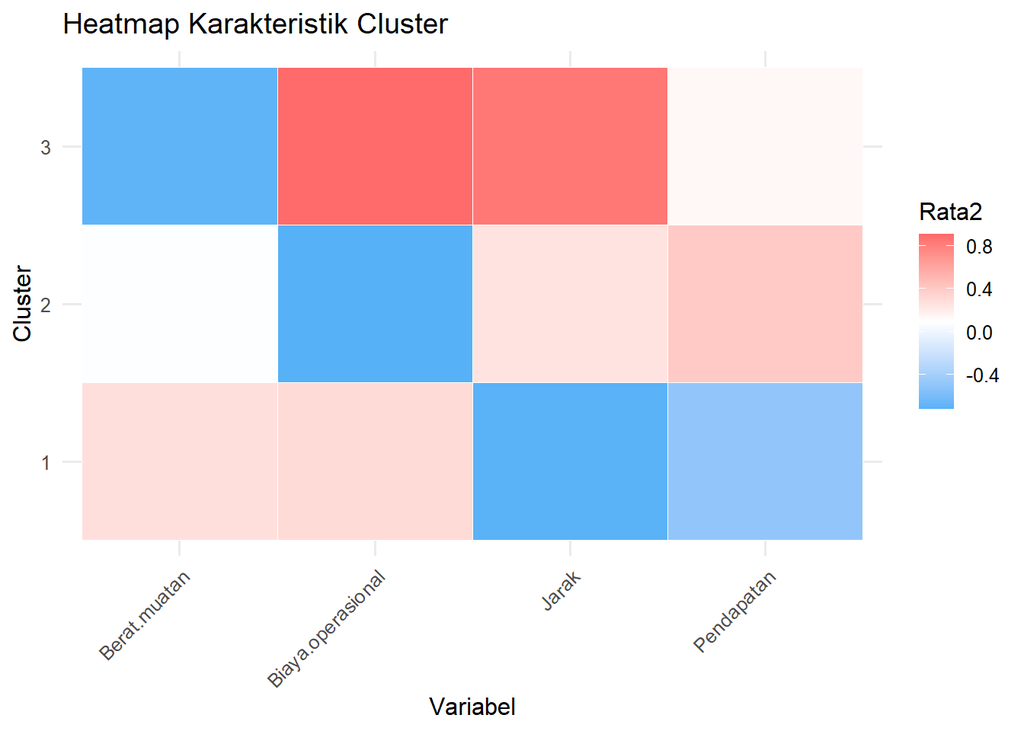

```r
ggplot(heat_data, aes(x = Variabel, y = cluster, fill = Rata2)) +
geom_tile(color = "white") +
scale_fill_gradientn(colors = c("#56B1F7", "white", "#FF6B6B")) +
labs(title = "Heatmap Karakteristik Cluster",
x = "Variabel", y = "Cluster") +
theme_minimal(base_size = 12) +
theme(axis.text.x = element_text(angle = 45, hjust = 1))
```

**Bar Plot**

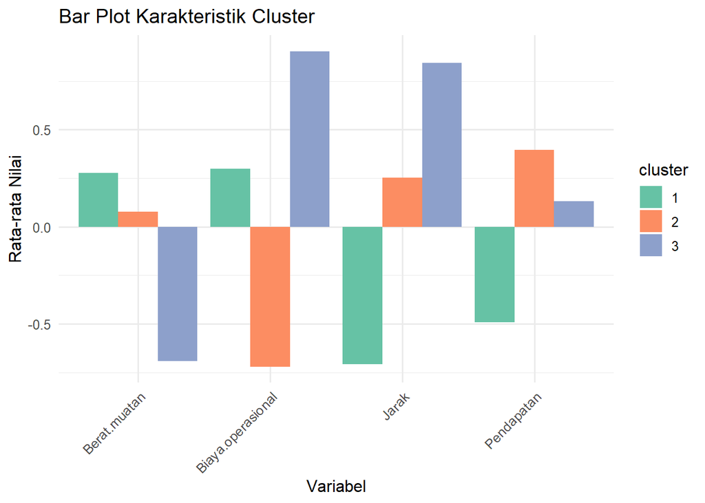

```r
ggplot(heat_data, aes(x = Variabel, y = Rata2, fill = cluster)) +
geom_bar(stat = "identity", position = "dodge") +
scale_fill_brewer(palette = "Set2") +
labs(title = "Bar Plot Karakteristik Cluster",
x = "Variabel", y = "Rata-rata Nilai") +
theme_minimal(base_size = 12) +
theme(axis.text.x = element_text(angle = 45, hjust = 1))
```

Berdasarkan bar plot karakteristik cluster di atas, terlihat bahwa setiap cluster memiliki ciri khas berbeda. - Cluster 1 ditandai dengan nilai rata-rata yang relatif tinggi pada variabel berat muatan dan biaya operasional, namun rendah pada jarak dan pendapatan.

- Cluster 3 menunjukkan karakteristik dominan pada biaya operasional dan jarak yang tinggi, namun berat muatan dan pendapatan lebih rendah. Secara keseluruhan, plot ini menunjukkan adanya perbedaan signifikan antar cluster, terutama pada variabel biaya operasional dan jarak yang menjadi pembeda utama antar kelompok.

## **B. K-Means Clustering**

## Menentukan Jumlah Cluster Optimal

Langkah pertama adalah menentukan jumlah cluster terbaik (*k*) menggunakan dua metode populer:

- **Elbow Method:** melihat titik siku (*elbow point*) pada grafik *within-cluster sum of squares (WSS)*.
- **Silhouette Method:** menilai kualitas pemisahan cluster; semakin tinggi nilai *silhouette*, semakin baik hasil clustering.

```r
library(factoextra)
library(cluster)
library(clusterCrit)
library(dplyr)
library(ggplot2)
library(tidyr)
library(scales)
library(RColorBrewer)
```

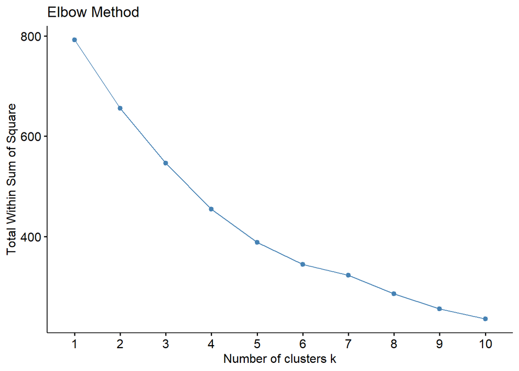

```r
fviz_nbclust(data_scaled, kmeans, method = "wss") +
labs(title = "Elbow Method")
```

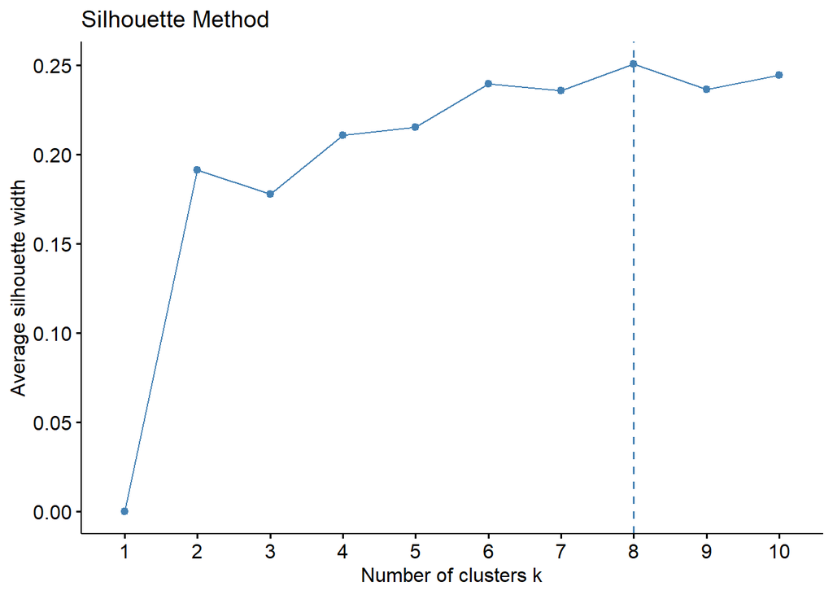

```r
fviz_nbclust(data_scaled, kmeans, method = "silhouette") +
labs(title = "Silhouette Method")
```

## Penerapan Algoritma K-Means

Setelah jumlah cluster optimal dipilih (misal k = 8), dilakukan proses clustering menggunakan fungsi `kmeans()`.

Parameter `nstart = 25` digunakan untuk memastikan stabilitas hasil dengan mencoba 25 inisialisasi acak.

```r
set.seed(123)
kmeans_result <- kmeans(data_scaled, centers = 8, nstart = 25)
kmeans_result
```

```
## K-means clustering with 8 clusters of sizes 18, 26, 26, 19, 36, 21, 25, 28
##
## Cluster means:
##        Jarak Berat.muatan Biaya.operasional Pendapatan
## 1  1.0396407    1.1334993         0.6856656  0.7321690
## 2 -0.3053605   -1.1403134        -1.0739320  0.1586807
## 3  0.4272565   -0.8128345         0.7017347  1.0934817
## 4 -0.9777095   -0.8626702         0.6030589 -0.7500707
## 5 -0.9280693    0.8205394         0.4746983 -0.2771851
## 6 -0.8043686    0.7315261        -0.9232303  1.0415366
## 7  0.8941151   -0.5147866         0.8056506 -0.8145501
## 8  0.8801076    0.5263497        -1.1416264 -0.8219205
##
## Clustering vector:
##   [1] 5 4 8 8 6 3 2 3 4 5 1 3 8 5 3 8 2 3 7 6 4 8 4 2 6 6 4 2 6 1 2 8 5 5 4 5 5
##  [38] 3 8 3 8 7 8 5 6 3 5 5 2 5 3 4 3 6 5 4 2 8 4 5 5 1 4 7 5 8 7 1 8 6 2 5 2 7
##  [75] 8 5 1 5 5 4 4 8 5 3 3 5 4 6 8 6 7 7 5 2 5 3 1 2 7 1 8 8 8 3 5 5 7 2 3 3 6
## [112] 7 5 8 5 7 4 5 2 6 4 7 8 7 4 6 5 8 5 2 1 8 2 2 8 2 3 7 7 7 7 7 5 6 5 8 7 1
## [149] 2 1 8 1 6 7 2 2 1 5 2 4 7 7 1 5 3 3 3 1 3 6 2 3 6 1 4 7 5 5 6 1 1 3 8 2 1
## [186] 3 6 7 4 3 6 7 6 3 2 2 8 2 8
##
## Within cluster sum of squares by cluster:
## [1] 28.69326 41.21294 32.95138 23.98593 45.50766 28.71944 33.20403 38.53215
##  (between_SS / total_SS =  65.6 %)
##
## Available components:
##
## [1] "cluster"      "centers"      "totss"        "withinss"     "tot.withinss"
## [6] "betweenss"    "size"         "iter"         "ifault"
```

## Hasil Clustering

```r
table(kmeans_result$cluster)
```

```
##
##  1  2  3  4  5  6  7  8
## 18 26 26 19 36 21 25 28
```

```r
head(data.frame(Observasi = 1:length(kmeans_result$cluster),
           Cluster = kmeans_result$cluster),10)
```

```
##    Observasi Cluster
## 1          1       5
## 2          2       4
## 3          3       8
## 4          4       8
## 5          5       6
## 6          6       3
## 7          7       2
## 8          8       3
## 9          9       4
## 10        10       5
```

## Komponen Hasil K-Means

Fungsi `kmeans()` menghasilkan sejumlah komponen penting untuk memahami hasil pengelompokan:

| Komponen | Penjelasan |
| --- | --- |
| `cluster` | Label cluster untuk setiap observasi |
| `centers` | Koordinat pusat (*centroid*) tiap cluster |
| `totss` | Total variasi data (Total Sum of Squares) |
| `withinss` | Variasi dalam masing-masing cluster |
| `tot.withinss` | Jumlah keseluruhan variasi dalam cluster |
| `betweenss` | Variasi antar cluster |
| `size` | Jumlah anggota setiap cluster |
| `iter` | Jumlah iterasi hingga konvergen |
| `ifault` | Status hasil (0 = sukses) |

```r
names(kmeans_result)
```

```
## [1] "cluster"      "centers"      "totss"        "withinss"     "tot.withinss"
## [6] "betweenss"    "size"         "iter"         "ifault"
```

```r
kmeans_result$cluster
```

```
##   [1] 5 4 8 8 6 3 2 3 4 5 1 3 8 5 3 8 2 3 7 6 4 8 4 2 6 6 4 2 6 1 2 8 5 5 4 5 5
##  [38] 3 8 3 8 7 8 5 6 3 5 5 2 5 3 4 3 6 5 4 2 8 4 5 5 1 4 7 5 8 7 1 8 6 2 5 2 7
##  [75] 8 5 1 5 5 4 4 8 5 3 3 5 4 6 8 6 7 7 5 2 5 3 1 2 7 1 8 8 8 3 5 5 7 2 3 3 6
## [112] 7 5 8 5 7 4 5 2 6 4 7 8 7 4 6 5 8 5 2 1 8 2 2 8 2 3 7 7 7 7 7 5 6 5 8 7 1
## [149] 2 1 8 1 6 7 2 2 1 5 2 4 7 7 1 5 3 3 3 1 3 6 2 3 6 1 4 7 5 5 6 1 1 3 8 2 1
## [186] 3 6 7 4 3 6 7 6 3 2 2 8 2 8
```

```r
kmeans_result$totss
```

```
## [1] 792
```

```r
kmeans_result$withinss
```

```
## [1] 28.69326 41.21294 32.95138 23.98593 45.50766 28.71944 33.20403 38.53215
```

```r
kmeans_result$tot.withinss
```

```
## [1] 272.8068
```

```r
kmeans_result$betweenss
```

```
## [1] 519.1932
```

```r
kmeans_result$iter
```

```
## [1] 3
```

## Evaluasi Clustering

```r
cluster_km <- kmeans_result$cluster
dist_matrix <- dist(data_scaled, method = "euclidean")

sil <- mean(silhouette(cluster_km, dist_matrix)[, 3])
ch <- intCriteria(traj = as.matrix(data_scaled),
part = cluster_km,
crit = "Calinski_Harabasz")$calinski_harabasz
dunn <- intCriteria(traj = as.matrix(data_scaled),
part = cluster_km,
crit = "Dunn")$dunn

data.frame(Silhouette = sil,
Calinski_Harabasz = ch,
Dunn = dunn)
```

```
##   Silhouette Calinski_Harabasz     Dunn
## 1  0.2557682          51.92891 0.123961
```

Berdasarkan hasil evaluasi, nilai Silhouette sebesar 0,256 menunjukkan bahwa struktur cluster sudah mulai terbentuk dengan cukup baik, meskipun masih ada sedikit tumpang tindih antar cluster. Nilai Calinski-Harabasz sebesar 51,93 menunjukkan adanya pemisahan yang lebih jelas antar cluster dibandingkan variasi di dalam cluster. Sementara itu, nilai Dunn sebesar 0,124 menandakan bahwa jarak antar cluster cukup terpisah dan konsisten.

## Karakteristik Cluster

```r
data_clustered <- data.frame(data_scaled, cluster = factor(cluster_km))

cluster_summary <- data_clustered %>%
group_by(cluster) %>%
summarise(across(where(is.numeric), mean, .names = "{.col}"))

cluster_summary
```

```
## # A tibble: 8 × 5
##   cluster  Jarak Berat.muatan Biaya.operasional Pendapatan
##   <fct>    <dbl>        <dbl>             <dbl>      <dbl>
## 1 1        1.04         1.13              0.686      0.732
## 2 2       -0.305       -1.14             -1.07       0.159
## 3 3        0.427       -0.813             0.702      1.09
## 4 4       -0.978       -0.863             0.603     -0.750
## 5 5       -0.928        0.821             0.475     -0.277
## 6 6       -0.804        0.732            -0.923      1.04
## 7 7        0.894       -0.515             0.806     -0.815
## 8 8        0.880        0.526            -1.14      -0.822
```

## Visualisasi Clustering

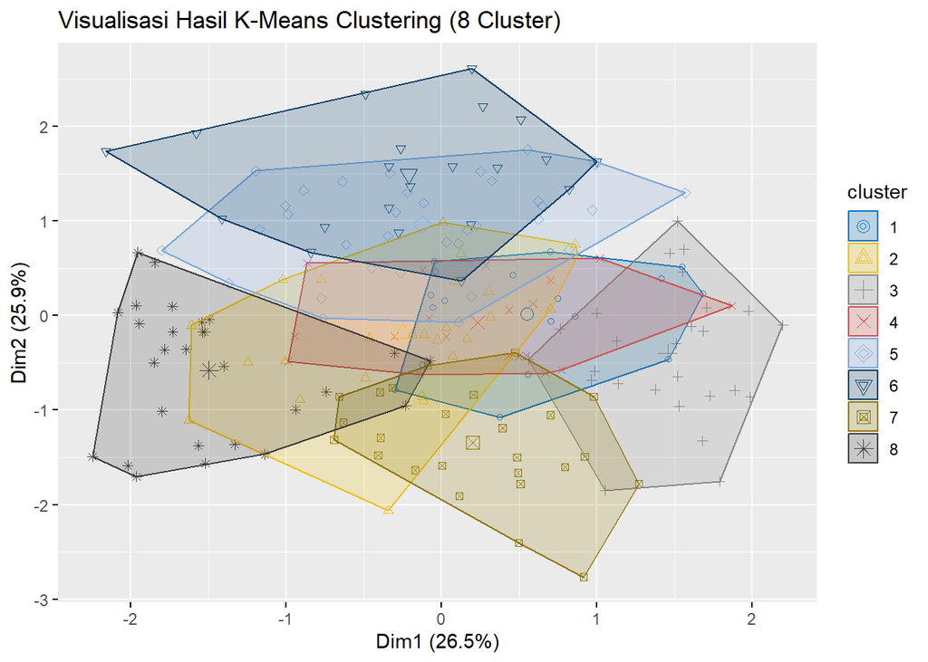

```r
fviz_cluster(kmeans_result, data = data_scaled,
palette = "jco", geom = "point",
main = "Visualisasi Hasil K-Means Clustering (8 Cluster)")
```

Berdasarkan visualisasi hasil K-Means Clustering dengan 8 cluster, terlihat bahwa data terbagi menjadi lebih banyak kelompok dengan batas wilayah yang saling tumpang tindih. Setiap cluster direpresentasikan oleh warna dan bentuk titik yang berbeda, namun distribusinya masih menunjukkan adanya kedekatan antar cluster. Hal ini mengindikasikan bahwa pembentukan delapan cluster menghasilkan segmentasi yang lebih detail, tetapi belum memberikan pemisahan yang jelas antar kelompok. Dimensi 1 (26,5%) dan Dimensi 2 (25,9%) tetap mampu menjelaskan sebagian besar variasi data, namun jumlah cluster yang terlalu banyak cenderung membuat struktur data menjadi kurang terpisah secara tegas.

```r
heat_data <- cluster_summary %>%
pivot_longer(-cluster, names_to = "Variabel", values_to = "Rata2")
heat_data
```

```
## # A tibble: 32 × 3
##    cluster Variabel           Rata2
##    <fct>   <chr>              <dbl>
##  1 1       Jarak              1.04
##  2 1       Berat.muatan       1.13
##  3 1       Biaya.operasional  0.686
##  4 1       Pendapatan         0.732
##  5 2       Jarak             -0.305
##  6 2       Berat.muatan      -1.14
##  7 2       Biaya.operasional -1.07
##  8 2       Pendapatan         0.159
##  9 3       Jarak              0.427
## 10 3       Berat.muatan      -0.813
## # ℹ 22 more rows
```

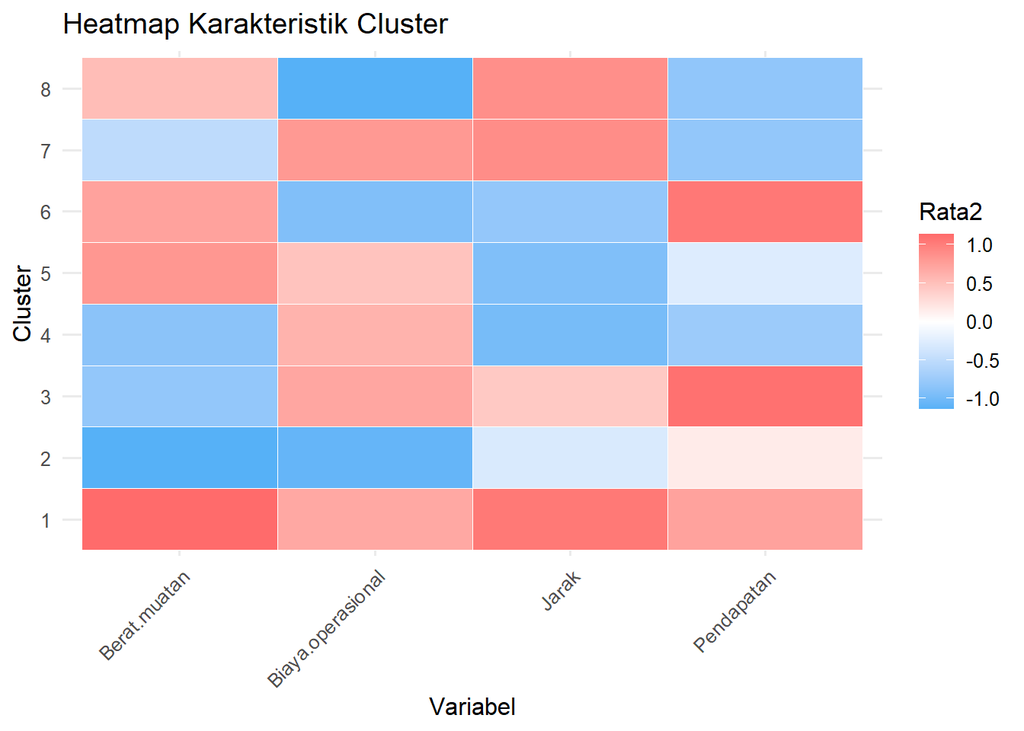

```r
ggplot(heat_data, aes(x = Variabel, y = cluster, fill = Rata2)) +
geom_tile(color = "white") +
scale_fill_gradientn(colors = c("#56B1F7", "white", "#FF6B6B")) +
labs(title = "Heatmap Karakteristik Cluster",
x = "Variabel", y = "Cluster") +
theme_minimal(base_size = 12) +
theme(axis.text.x = element_text(angle = 45, hjust = 1))
```

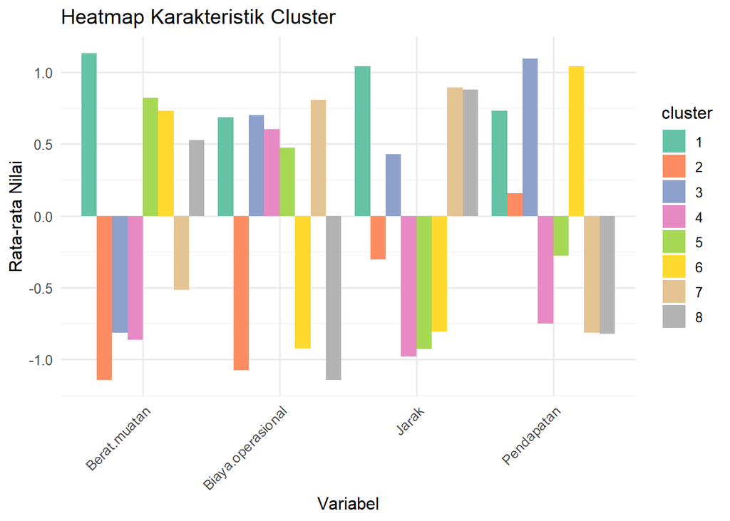

```r
ggplot(heat_data, aes(x = Variabel, y = Rata2, fill = cluster)) +
geom_bar(stat = "identity", position = "dodge") +
scale_fill_brewer(palette = "Set2") +
labs(title = "Heatmap Karakteristik Cluster",
x = "Variabel", y = "Rata-rata Nilai") +
theme_minimal(base_size = 12) +
theme(axis.text.x = element_text(angle = 45, hjust = 1))
```

**Penjelasan***:*

Secara keseluruhan, baik metode Hierarchical Clustering maupun metode K-Means Clustering menunjukkan hasil clustering yang cukup baik, namun belum optimal.

Pada metode Hierarchical Clustering, nilai Silhouette sebesar 0,156 dan Dunn 0,099 menunjukkan bahwa pemisahan antar kelompok masih lemah dan terdapat tumpang tindih antar cluster. Artinya, struktur data belum terbentuk dengan jelas sehingga hasil segmentasi masih bisa ditingkatkan.

Sementara itu, metode K-Means Clustering menunjukkan peningkatan performa dengan Silhouette 0,256, Calinski-Harabasz 51,93, dan Dunn 0,124, yang menandakan adanya pemisahan antar cluster yang lebih baik dan komposisi data yang lebih kompak di dalam cluster. Meski demikian, dari sisi visualisasi masih terlihat beberapa area yang saling beririsan, sehingga pembentukan cluster belum sepenuhnya sempurna.

Dengan demikian, dapat disimpulkan bahwa metode K-Means Clustering lebih baik dibandingkan metode Hierarchical Clustering secara metrik evaluasi, namun keduanya masih bisa ditingkatkan agar menghasilkan pemisahan kelompok yang lebih jelas dan interpretasi yang lebih kuat.